# AID TP01

German Beldorati Stark

```r
library(tidyverse)
theme_set(theme_classic())
```

# load + wrangling

## clientes

```r
clientes <- read_csv("data/DNA_03_NEW.csv.bz2") %>%
  janitor::clean_names()
```

Investigo columna `base_stat_03`, cambiandola a `factor`. Viendo los niveles, me saco de encima las filas que no me interesan, lease, las que no son “ACTIVE BASE” o “REJOINER”

```r
clientes %>% mutate(base_stat_03 = factor(base_stat_03)) -> clientes

clientes %>%
  select(-x1) %>%
  filter(base_stat_03 %in% c("ACTIVE BASE", "REJOINNER")) -> clientes
```

## recargas

```r
rec01 <- read_csv("data/RECA_CHAN_01_NEW.csv.bz2")
rec02 <- read_csv("data/RECA_CHAN_02_NEW.csv.bz2")
rec03 <- read_csv("data/RECA_CHAN_03_NEW.csv.bz2")
```

Defino una función de limpieza para las bases correspondientes a enero, febrero y marzo. Limpia los nombres, y genera las columnas nuevas necesarias para el posterior análisis.

```r
limpio_recargas <- function(x) {
  x %>% janitor::clean_names() %>%
  select(-x1) %>%
  filter(purchaseamount > 0) %>%
  mutate(purchasetime = lubridate::parse_date_time(purchasetime, "d b Y H M S"),
         month = lubridate::month(purchasetime, label = TRUE),
         channel_type = if_else(
           str_detect(channelidentifier, "EMG"),
           true = "tecno", false = "manual"
           )
         )
}
```

Aplico la función de limpieza y uno los dataframes de recargas en uno solo.

```r
list(rec01, rec02, rec03) %>%
  map(limpio_recargas) %>%
  reduce(bind_rows) -> recargas
```

## joining

Uno las tablas `recarga` y `clientes`, mediante un inner join, ya que no me interesan los clientes para los cuales no tengo información de recargas, ni las recargas de clientes que no tengan `base_stat_03` == REJOINNER o ACTIVE BASE.

NOTA: Tiempo despues de hacer esto, me entere por compañerxs que habia que preservar los datos de los clientes que no hicieron recargas. Para esto, en vez de un inner, bastaria hacer un outer join (left, manteniendo el orden de las tablas como esta.). Todas estas observaciones caerian en la clase “99-NOSEGM”, dado que su cantidad de recargas seria cero. Si bien dudo que se modifiquen las observaciones que siguen, por cuestiones de tiempo elijo entregar la version original en el script, pero adjuntar la tabla correcta, con el codigo para generarla en el anexo.

```r
db <- clientes %>%
  inner_join(recargas, by = c("accs_mthd_cd" = "customerid"))
```

## limpieza

Elimino tablas simples para ahorrar memoria.

```r
rm(list = c(ls(pattern = "rec\\d"), "recargas"))
```

# Clientes_Mar21

Calculo valores totales en tabla `db_total` y unicamente las tecnológicas en `db_tecno`. Luego las uno (mediante un `left_join`, preservando a todos los clientes, independientemente del tipo de recarga) y reemplazo los NA (que aparecen en caso de no haber realizado cargas por medios tecnológicos) por ceros. Almaceno todo en `db_joined`.

```r
db_total <-
  db %>%
  group_by(accs_mthd_cd) %>%
  summarise(
    monto_total = sum(purchaseamount),
    cant_recargas = n()
  )

db_tecno <-
  db %>%
  filter(channel_type == "tecno") %>%
  group_by(accs_mthd_cd) %>%
  summarise(
    monto_tecno = sum(purchaseamount),
    cant_rtec = n()
  )

db_joined <-
  db_total %>%
  left_join(db_tecno, by = "accs_mthd_cd") %>%
  # cantidad de regargas seguro es int, monto_tecno no necesariamente.
  replace_na(list(monto_tecno = 0, cant_rtec = 0L))
```

Luego, calculo las variables que requieren de los totales y marginales.

```r
Clientes_Mar21 <-
  db_joined %>%
  mutate(
    por_tecno_m = monto_tecno / monto_total * 100,
    por_tecno = cant_rtec / cant_recargas * 100,
    cl_tecno = case_when(
      por_tecno >= 70 ~ "1-Tecno",
      por_tecno >= 40 & por_tecno < 70 ~ "2-Mix4070",
      por_tecno > 0 & por_tecno < 40 ~ "3-MixH40",
      por_tecno == 0 ~ "4-No Tecno",
      TRUE ~ "ERROR"
    ),
    cl_tecno = case_when(
      cant_recargas >= 3 ~ cl_tecno,
      cant_recargas < 3 ~ "99-NOSEGM",
      TRUE ~ "ERROR"
    )
  )
```

Finalmente agrego la columna `base_stat_03`, que se perdió en un `summarise`.

```r
Clientes_Mar21 <-
  Clientes_Mar21 %>%
    inner_join(clientes, by = "accs_mthd_cd")

rm(clientes)
```

# Segmentacion_Mar21

Calculo los resúmenes pedidos.

```r
Segmentacion_Mar21 <-
  Clientes_Mar21 %>%
  group_by(cl_tecno) %>%
  summarise(
    monto_total_promedio = mean(monto_total),
    monto_tecno_promedio = mean(monto_tecno),
    cant_recargas_promedio = mean(cant_recargas),
    cant_rec_tecno_promedio = mean(cant_rtec)
  )
```

# descriptiva

La variable `accs_mthd_cd` no es “numérica” hablando estrictamente, por lo que la transformo en factor para que `skim` no calcule estadísticos que no tienen sentido.

```r
skimr::skim(Clientes_Mar21 %>% mutate(accs_mthd_cd = factor(accs_mthd_cd)))
```

Data summary

| Name | Clientes_Mar21 %>% mutate… |
| --- | --- |
| Number of rows | 1054833 |
| Number of columns | 9 |
| _______________________ |  |
| Column type frequency: |  |
| character | 1 |
| factor | 2 |
| numeric | 6 |
| ________________________ |  |
| Group variables | None |

**Variable type: character**

| skim_variable | n_missing | complete_rate | min | max | empty | n_unique | whitespace |
| --- | --- | --- | --- | --- | --- | --- | --- |
| cl_tecno | 0 | 1 | 7 | 10 | 0 | 5 | 0 |

**Variable type: factor**

| skim_variable | n_missing | complete_rate | ordered | n_unique | top_counts |
| --- | --- | --- | --- | --- | --- |
| accs_mthd_cd | 0 | 1 | FALSE | 1054833 | 120: 1, 120: 1, 120: 1, 120: 1 |
| base_stat_03 | 0 | 1 | FALSE | 2 | ACT: 1034521, REJ: 20312, GRO: 0 |

**Variable type: numeric**

| skim_variable | n_missing | complete_rate | mean | sd | p0 | p25 | p50 | p75 | p100 | hist |
| --- | --- | --- | --- | --- | --- | --- | --- | --- | --- | --- |
| monto_total | 0 | 1 | 31.29 | 26.76 | 0.93 | 9.5 | 25 | 50.00 | 1140 | ▇▁▁▁▁ |
| cant_recargas | 0 | 1 | 7.12 | 5.70 | 1.00 | 2.0 | 6 | 11.00 | 226 | ▇▁▁▁▁ |
| monto_tecno | 0 | 1 | 5.99 | 15.53 | 0.00 | 0.0 | 0 | 5.00 | 845 | ▇▁▁▁▁ |
| cant_rtec | 0 | 1 | 1.23 | 2.94 | 0.00 | 0.0 | 0 | 1.00 | 136 | ▇▁▁▁▁ |
| por_tecno_m | 0 | 1 | 18.23 | 33.38 | 0.00 | 0.0 | 0 | 18.75 | 100 | ▇▁▁▁▁ |
| por_tecno | 0 | 1 | 18.14 | 33.23 | 0.00 | 0.0 | 0 | 18.75 | 100 | ▇▁▁▁▁ |

# graficos

## segmentacion

Primero grafico unos histogramas, para ver las distribuciones de regargas y montos en cada nivel de clasificación. En todos los casos, se observa la presencia de outliers: tanto en las medidas de descriptiva (los cuantiles en particular), como también en los histogramas (se nota por la escala del gráfico, pero luego se ve mejor en los gráficos de dispersión).

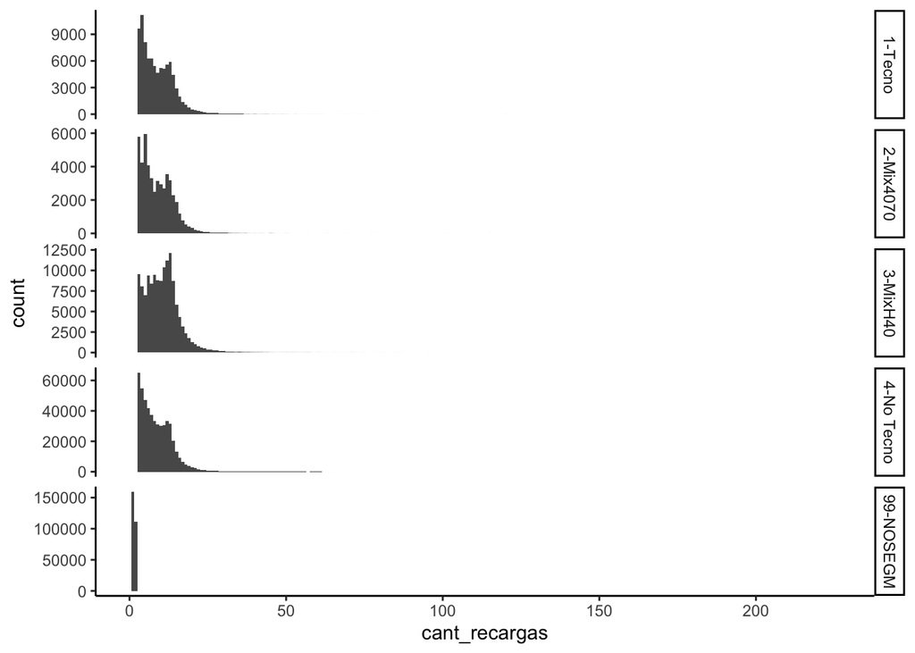

```r
Clientes_Mar21 %>%
  ggplot(aes(cant_recargas)) +
  geom_histogram(binwidth = 1) +
  facet_grid(cl_tecno ~ ., scales = "free")
```

Las distribuciones de cantidad de recargas en varios casos tienen pinta bimodal. Una hipótesis es que la gente hace pocas recargas de montos altos, o muchas recargas de montos chicos.

Filtrando la cantidad de recargas a menos de 75 perdemos unicamente 80 datos, y se ve mejor la pinta de las distribuciones.

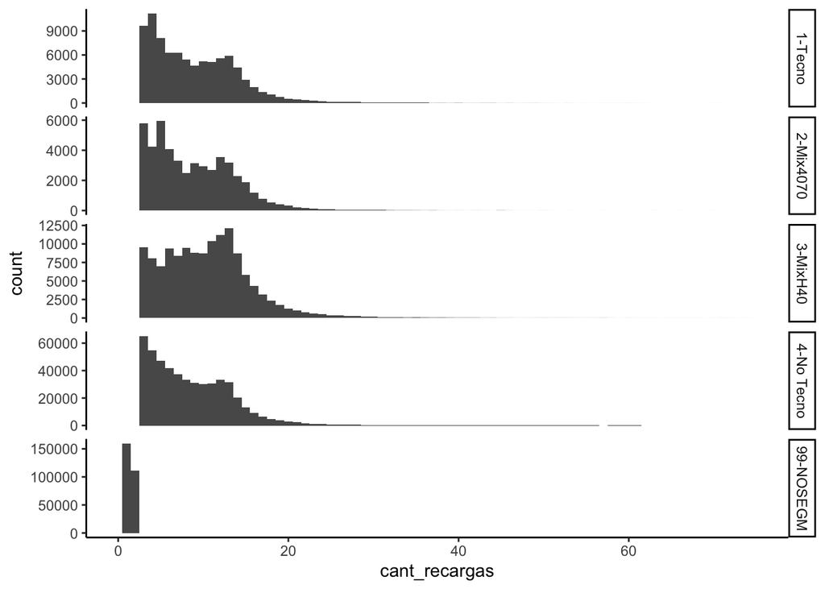

```r
Clientes_Mar21 %>%
  ggplot(aes(cant_recargas)) +
  geom_histogram(binwidth = 1) +
  facet_grid(cl_tecno ~ ., scales = "free") +
  xlim(c(0, 75))
```

Al graficar los montos, también vemos cierta bimodalidad, lo cual soporta la hipótesis. Para estudiarlo con mas detalle podria clasificar en dos, separando a *grosso modo* las dos modas de una de las variables, y graficar la distribución de la otra. O más fácil, graficar la conjunta directamente, mediante un scatterplot.

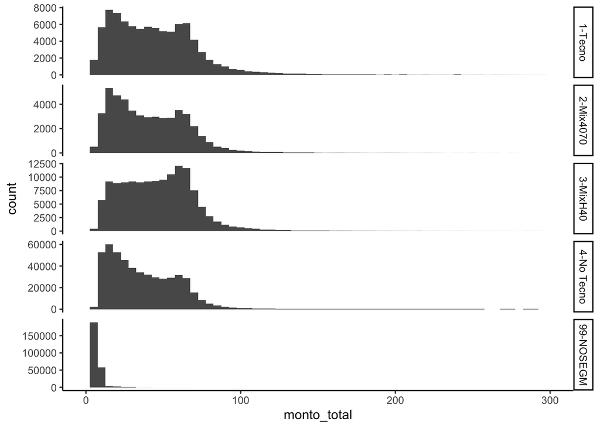

```r
# en este caso, filtrando el monto total a menores de 300 perdemos ~250 datos unicamente.
Clientes_Mar21 %>%
  ggplot(aes(monto_total)) +
  geom_histogram(binwidth = 5) +
  facet_grid(cl_tecno ~ ., scales = "free") +
  xlim(c(0, 300))
```

Puedo visualizar con un gráfico de densidades también, ya que monto_total es una variable en principio contínua, y tenemos bastantes observaciones.

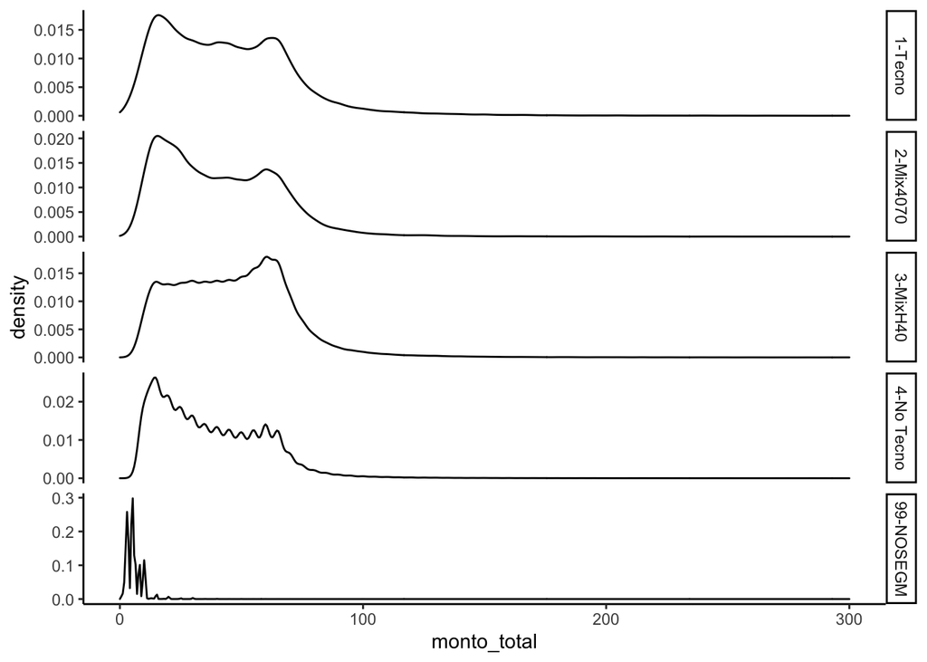

```r
Clientes_Mar21 %>%
  ggplot(aes(monto_total)) +
  geom_density() +
  facet_grid(cl_tecno ~ ., scales = "free") +
  xlim(c(0, 300))
```

Luego, grafico un scatterplot, que debido al numero de observaciones tarda mucho, y esta lleno de overplotting, por mas `alpha` o mas chiquito el tamaño del punto use. (probé tambien hacer un subsampleo estratificado, manteniendo las proporciones de los grupos, pero tendria que hacerlo con más detalle. Dejo el codigo en un anexo al final para referencia futura.)

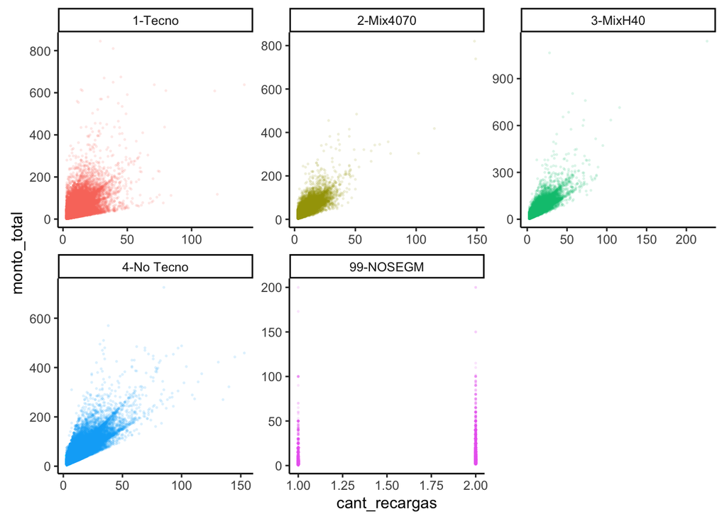

```r
Clientes_Mar21 %>%
  ggplot(aes(cant_recargas, monto_total, color = cl_tecno)) +
  geom_point(alpha = 0.1, size = 0.31) +
  facet_wrap(~cl_tecno, scale = "free") +
  theme(aspect.ratio = 1, legend.position = "none")
```

Una forma de “limpiar” los scatterplots es usando `geom_hex`, que básicamente grafica la frecuencia de regiones hexagonales, mappeando el numero de observaciones dentro de la region al estético “color”.

Además, como el rango de observaciones es muy amplio (hay zonas muy concentradas en observaciones y otras prácticamente vacias), transformo logarítmicamente las frecuencias para asi poder observar un gradiente en las frecuencias.

En otras palabras, esto básicamente grafica la distribucion conjunta de los datos con respecto a estas variables.

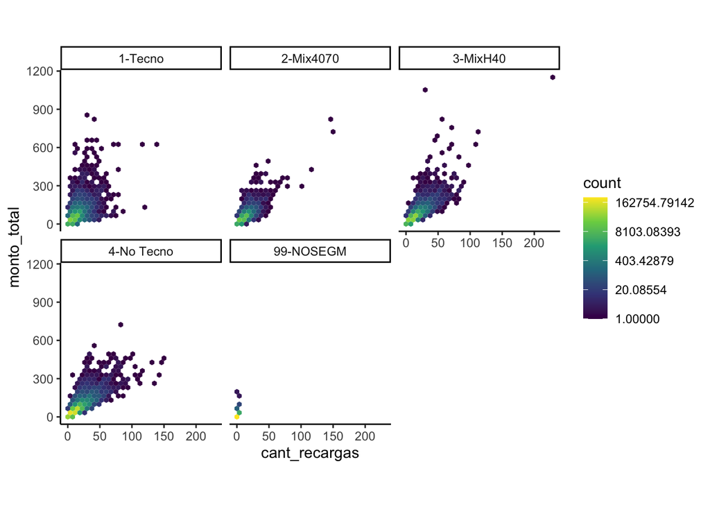

```r
Clientes_Mar21 %>%
  ggplot(aes(cant_recargas, monto_total)) +
  geom_hex() +
  scale_fill_viridis_c(trans = "log") +
  facet_wrap(~cl_tecno) +
  theme(aspect.ratio = 1)
```

Lo que podemos ver es que en el segmento 1 hay una mayor cantidad de datos en la region correspondiente a poca cantidad de recargas y montos altos, mientras que en el 4 no, la nube tiende esta mas desplazada hacia abajo (montos menores).

## tipo de cliente

Luego, explorando la clasificación por `base_stat_03`, vemos que son muy pocos los clientes “REJOINNER”. Y además, no son la subpoblación que nos genera la bimodalidad.

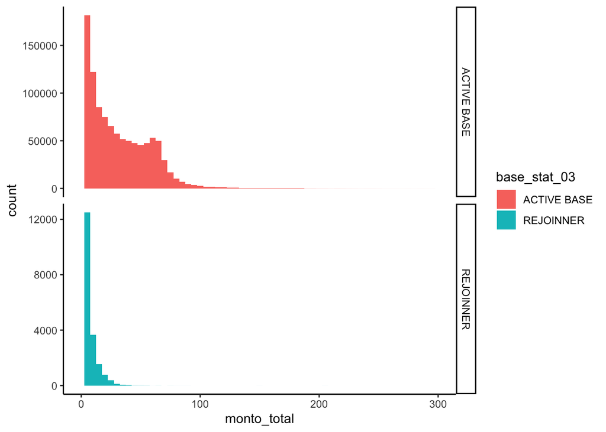

```r
Clientes_Mar21 %>%
  #filter(base_stat_03 == "REJOINNER") %>%
  ggplot(aes(monto_total, fill = base_stat_03)) +
  geom_histogram(binwidth = 5) +
  facet_grid(base_stat_03~., scale = "free") +
  xlim(c(0, 300))
```

El gráfico de densidades es ruidoso, probablemente porque monto total no es estrictamente continuo en este dataset. Más aún, tiene sólo 4991 valores posibles.

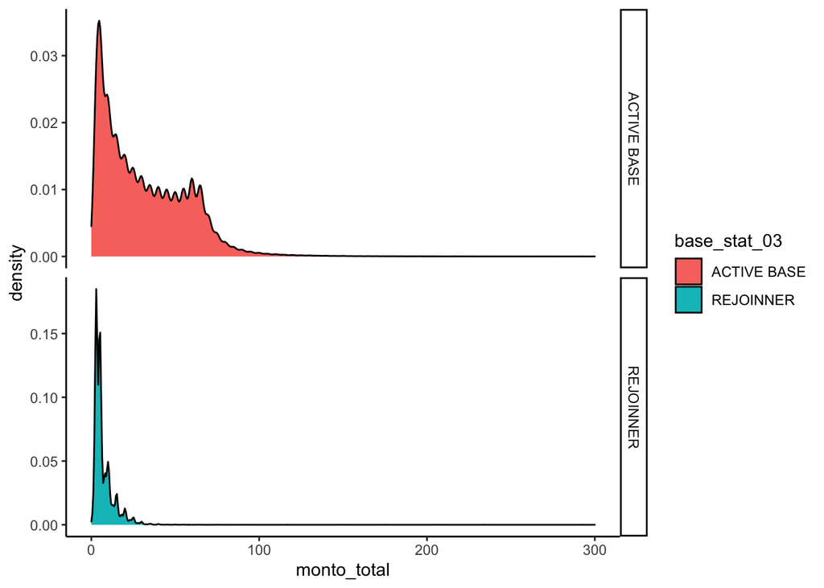

```r
Clientes_Mar21 %>%
  #filter(base_stat_03 == "REJOINNER") %>%
  ggplot(aes(monto_total, fill = base_stat_03)) +
  geom_density() +
  facet_grid(base_stat_03~., scale = "free") +
  xlim(c(0, 300))
```

# anexo

## Tabla clientes correcta

```r
db <- clientes %>%
  left_join(recargas, by = c("accs_mthd_cd" = "customerid"))

db_total <-
  db %>%
  group_by(accs_mthd_cd) %>%
  summarise(
    # reemplazo los NA por cero, gente que no recargo nunca
    monto_total = sum(replace_na(purchaseamount, 0)),
    # primero cuento las filas para la cantidad de recargas
    cant_recargas = n(),
    # luego reemplazo las que corresponden a gente que no cargo.
    cant_recargas = if_else(is.na(channel_type), 0L, cant_recargas)
  )

db_tecno <-
  db %>%
  filter(channel_type == "tecno") %>%
  group_by(accs_mthd_cd) %>%
  summarise(
    monto_tecno = sum(purchaseamount),
    cant_rtec = n()
  )

db_joined <-
  db_total %>%
  left_join(db_tecno, by = "accs_mthd_cd") %>%
  # cantidad de regargas seguro es int, monto_tecno no necesariamente.
  replace_na(list(monto_tecno = 0, cant_rtec = 0L)) %>% unique()

Clientes_Mar21_real <-
  db_joined %>%
  mutate(
    por_tecno_m = if_else(monto_total != 0, monto_tecno / monto_total * 100, 0),
    por_tecno = if_else(cant_recargas != 0, cant_rtec / cant_recargas * 100, 0),
    cl_tecno = case_when(
      por_tecno >= 70 ~ "1-Tecno",
      por_tecno >= 40 & por_tecno < 70 ~ "2-Mix4070",
      por_tecno > 0 & por_tecno < 40 ~ "3-MixH40",
      por_tecno == 0 ~ "4-No Tecno",
      TRUE ~ "ERROR"
    ),
    cl_tecno = case_when(
      cant_recargas >= 3 ~ cl_tecno,
      cant_recargas < 3 ~ "99-NOSEGM",
      TRUE ~ "ERROR"
    )
  )

Clientes_Mar21_real <-
  Clientes_Mar21_real %>%
    inner_join(clientes, by = "accs_mthd_cd")
```

## stratified subsampling

```r
clientes_subset <-
  Clientes_Mar21 %>%
  group_by(cl_tecno) %>%
  mutate(n_rows = n()) %>%
  sample_frac(0.3, weight = n_rows) %>%
  select(-n_rows) %>%
  ungroup()
```

## exportar tablas

Cambio capitalización de los nombres de variables y ordeno por id de cliente, para igualar a lo pedido en el TP. Exporto las tablas a csv.

```r
names(Clientes_Mar21_real) <- str_to_upper(names(Clientes_Mar21_real))

Clientes_Mar21_real %>%
  relocate(BASE_STAT_03, .after = ACCS_MTHD_CD) %>%
  arrange(ACCS_MTHD_CD) %>%
  write_csv("tabla1_clientes.csv.bz2")

Segmentacion_Mar21 %>% write_csv("tabla2_segmentacion.csv")
```